# PISA Data 2012 – What influences students' school performance?

## by Zora Schärer

## Investigation Overview

In this project I looked at the variables that potentially influence the performance of students around the world in three different areas: mathematics, reading and science. I chose three different domains of independent variables: students characteristics, social/family background and school characteristics.

## Distribution of plausible values

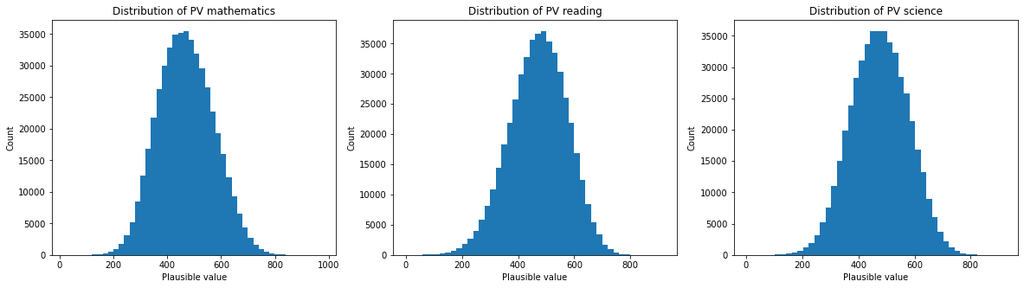

```python
plt.figure(figsize = [20, 5])
# math_pv
plt.subplot(1,3,1)
plot_hist(pisa_explore.math_pv, 20)
plt.title('Distribution of PV mathematics')
# reading_pv
plt.subplot(1,3,2)
plot_hist(pisa_explore.reading_pv, 20)
plt.title('Distribution of PV reading');
# science_pv
plt.subplot(1,3,3)
plot_hist(pisa_explore.science_pv, 20)
plt.title('Distribution of PV science');
```

## Correlation matrix

The correlation matrix reveals three main insights:

- Students generally perform well at school and not in one isolated area (correlation between PVs)
- The social and economic background of the family plays a vital role regarding the school performance of students (correlation between PVs and status)
- A positive feeling towards the teacher is related to a postive feeling towards the school (correlation between Student-teacher realtionship and attitude/belonging to school)

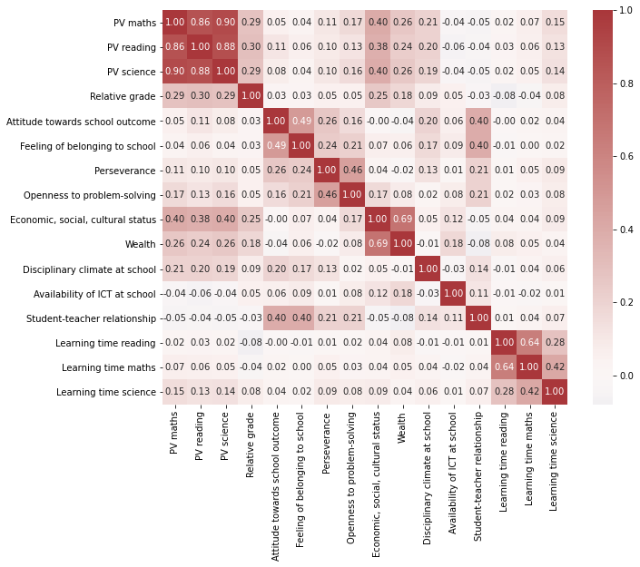

```python
# correlation matrix numerical variables
num_vars = ['math_pv','reading_pv','science_pv','rel_grade','attitude_school', 'belonging_school',
                'perseverance', 'problem_solving', 'status', 'wealth', 'discipl_climate',
                 'ICT_school', 'teacher_student_rel', 'l_learning', 'm_learning', 's_learning'] # numerical variables
plt.figure(figsize = [10, 8])
sb.heatmap(pisa_explore[num_vars].corr(), annot = True, fmt = '.2f', cmap = 'vlag', center = 0);
plt.xticks(np.arange(.5,16.5), ['PV maths','PV reading','PV science','Relative grade','Attitude towards school outcome',
                                'Feeling of belonging to school', 'Perseverance', 'Openness to problem-solving',
                                'Economic, social, cultural status', 'Wealth', 'Disciplinary climate at school',
                                 'Availability of ICT at school', 'Student-teacher relationship',
                                'Learning time reading', 'Learning time maths', 'Learning time science'], rotation = 90);
plt.yticks(np.arange(.5,16.5), ['PV maths','PV reading','PV science','Relative grade','Attitude towards school outcome',
                                'Feeling of belonging to school', 'Perseverance', 'Openness to problem-solving',
                                'Economic, social, cultural status', 'Wealth', 'Disciplinary climate at school',
                                 'Availability of ICT at school', 'Student-teacher relationship',
                                'Learning time reading', 'Learning time maths', 'Learning time science']);
```

## Country ranking

The following figure shows the mean PVs for all three areas in each country, while the countries are ordered by the PV for mathematics. This reveals the country ranking as well as the ranking of the three areas in each country.

One can see that in the four top countries students performed best in maths, while at the other end of the scale they performed worst in maths.

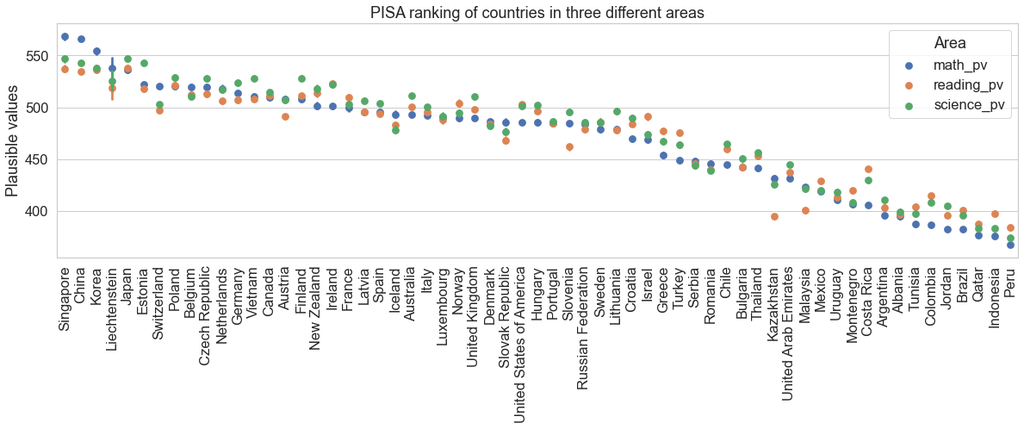

```python
# plot all three areas by country in one figure
# order countries by math_pv
country_order = pisa_explore.groupby('country').mean().math_pv.sort_values(axis = 0, ascending = False).index
# plot
plt.figure(figsize = [20, 5]);
sb.set(font_scale = 1.5);
sb.set_style("whitegrid");
sb.pointplot(data = pisa_long, x = 'country', y = 'pv', hue = 'area', linestyles = '', order = country_order)
plt.xticks(rotation = 90);
plt.title('PISA ranking of countries in three different areas')
plt.xlabel('');
plt.ylabel('Plausible values');
plt.legend(title = 'Area');
```

## School performance vs. parents' education I

The performance at school of students seems to be partly dependent on the education of their parents. This can be seen in the increasing PVs with increasing education level.

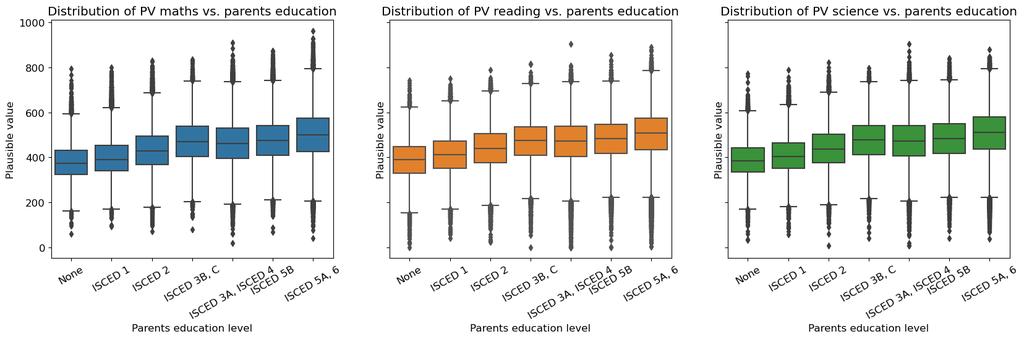

```python
matplotlib.rc_file_defaults()
plt.rcParams.update({'font.size': 12});

fig, ax = plt.subplots(ncols = 3, figsize = [20, 5], sharey = True)
# maths
sb.boxplot(data = pisa_explore, x = 'parents_edu', y = 'math_pv', color = sb.color_palette()[0], ax = ax[0]);
ax[0].set_xticklabels(labels = parents_edu_order, rotation = 30);
ax[0].set_xlabel('Parents education level');
ax[0].set_ylabel('Plausible value');
ax[0].set_title('Distribution of PV maths vs. parents education');
# reading
sb.boxplot(data = pisa_explore, x = 'parents_edu', y = 'reading_pv', color = sb.color_palette()[1], ax = ax[1]);
ax[1].set_xticklabels(labels = parents_edu_order, rotation = 30);
ax[1].set_xlabel('Parents education level');
ax[1].set_ylabel('Plausible value');
ax[1].set_title('Distribution of PV reading vs. parents education');
# science
sb.boxplot(data = pisa_explore, x = 'parents_edu', y = 'science_pv', color = sb.color_palette()[2], ax = ax[2]);
ax[2].set_xticklabels(labels = parents_edu_order, rotation = 30);
ax[2].set_xlabel('Parents education level');
ax[2].set_ylabel('Plausible value');
ax[2].set_title('Distribution of PV science vs. parents education');
```

## School performance vs. parents' education II

However, it is rather in the high performing countries that the parents education had an influence on the PVs. This was especially clear for reading and science. In countries with low PISA performance the education level of parents seems to have almost no influence.

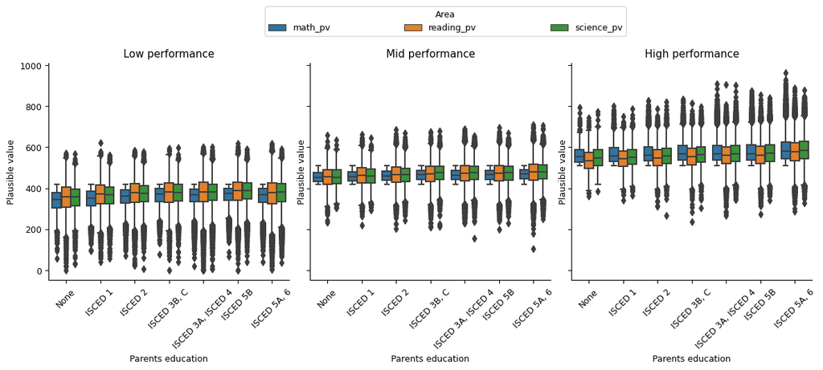

```python
plt.rcParams.update({'font.size': 9});
g = sb.FacetGrid(data = pisa_long, col = 'performance', height = 4);
g.map(sb.boxplot, 'parents_edu', 'pv','area', palette = 'tab10');
[ax.set_xlabel('Parents education') for ax in g.axes.flat];
[ax.set_ylabel('Plausible value') for ax in g.axes.flat];
[plt.setp(ax.get_xticklabels(), rotation = 45) for ax in g.axes.flat];
g.axes[0][0].legend(title = 'Area', bbox_to_anchor=(.9, 1.09, 1.5, .17), ncol = 3, mode = "expand", borderaxespad=0.);
g.axes[0][0].set_title('Low performance');
g.axes[0][1].set_title('Mid performance');
g.axes[0][2].set_title('High performance');
```